# Activité : mise en oeuvre d’un périphérique réseau (caméra IP)

Thierry Vaira <>

Site : [tvaira.free.fr](http://tvaira.free.fr/)

## Cahier des charges

Vous intervenez en équipe en tant que technicien IR dans une entreprise spécialisée dans les systèmes numériques. Vous venez de recevoir une caméra IP correspondant à vos besoins et vous devez :

- identifier les informations techniques nécessaire à sa prise en charge
- intégrer le nouveau matériel au système
- rendre opérationnel sa mise en oeuvre
- réaliser la recette de son installation
- développer un module logiciel minimal
- rendre la solution opérationnelle et la documenter

## Pré-requis

- connaissance des commandes de base du système GNU/Linux
- connaissance des réseaux TCP/IP
- connaissances en programmation C/C++ et en programmation orienté objet (POO)

## Exigences

- équipe de 3 étudiants
- assurer un compte-rendu oral et être capable de répondre à des questions techniques
- paramétrer le français comme langue par défaut du système de gestion web de la caméra
- estimer le niveau de sécurité d’une installation basée sur cette caméra
- livrer un programme source C++ de nom `camera.cpp` … qui permet :
  - d’afficher en temps réel le flux vidéo de la caméra dans une fenêtre
  - de capturer et sauvegarder des images lorsqu’on appuie sur la touche barre Espace
  - d’orienter la caméra avec les flèches du clavier

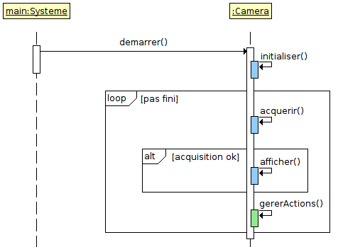

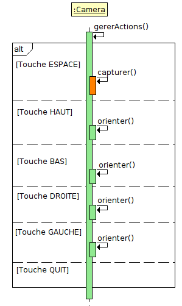

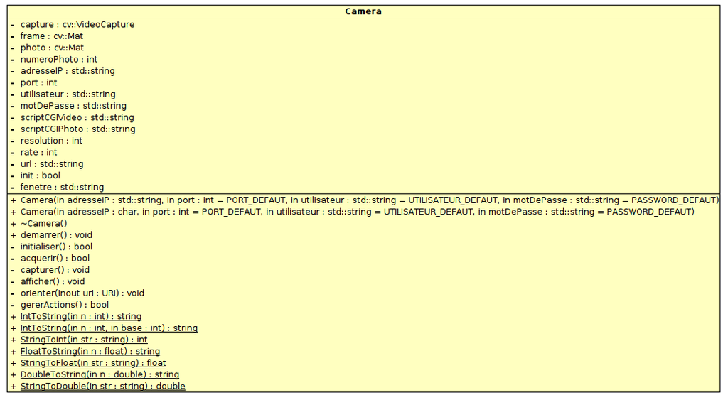

## Ressources documentaires

- Mise en oeuvre d’une caméra IP Wanscam
- Mise en oeuvre réseau d’une caméra IP Wanscam
- Mise en oeuvre d’OpenCV
- Mise en oeuvre de POCO
- Aide réseau
- Les formats d’image
- Questionnaire

## Ressources d’environnement

- Système d’exploitation : GNU/Linux (Ubuntu 12.04.5 LTS)
- Environnement de développement : Geany 1.24.1
- Compilateur : GNU g++/gcc version 4.6.3
- Chaîne de fabrication : GNU make 3.81
- Bibliothèques : [OpenCV](http://docs.opencv.org/), [POCO](http://pocoproject.org/)
- Sources : camera-todo.zip

## Matériel

- [Caméra Wanscam JW0008](http://www.wanscam.com/products/Electronics/)

## Compétences et Savoir-faire

- A1. Rechercher et/ou exploiter des documents …
  - T1.2 Extraire et synthétiser l’information pertinente.
    - C1.1 Rechercher et structurer des informations techniques.
      - SF01. Déterminer les critères de recherche et identifier les informations disponibles.
- A7. Réaliser ou mettre en oeuvre et valider une solution.
  - T7.2 Produire un prototype logiciel et/ou matériel.
    - C4.1 Câbler et/ou intégrer un matériel.
      - SF35. Réaliser la mise en situation et interconnecter du matériel.
    - C4.2 Adapter et/ou configurer un matériel.
      - SF36. Rendre opérationnel un matériel.
    - C4.3 Installer et configurer une chaîne de développement
      - SF38. Fournir un environnement de développement opérationnel.
    - C4.4 Développer un module logiciel.
      - SF42. S’assurer de la conformité du logiciel avec le cahier des charges.
  - T7.3 Valider le prototype.
    - C4.5 Tester et valider un module logiciel et matériel.
      - SF44. Faire la recette d’un module.
    - C4.6 : intégrer un module logiciel
      - SF46. Rendre opérationnel le système ou le sous-système.
- A9. Elaborer et/ou mettre en oeuvre le processus de réception …
  - T9.2 Installer un système ou un service.
    - C5.1 Préparer la solution et le plan d’action.
      - SF49. Le système est opérationnel et documenté.
    - C5.2 Mettre en oeuvre une solution matérielle/logicielle en situation.
      - SF50. Rendre la solution opérationnelle et la documenter.

Retour au sommaire